# 000947_TurnerLab_public_demo_000947_demo_ipynb

## Installing requirements

The cell below installs every Python package needed to run this notebook, at fully pinned versions, using [`uv`](https://github.com/astral-sh/uv) for fast resolution. In Colab the cell is collapsed by default — click the ▶ button to run it.

```python
# install cell skipped during CI (deps preinstalled into system Python)
```

> **⚠️ Restart runtime after install**

> The install may upgrade packages already loaded in the kernel. Go to **Runtime → Restart session**, then **Run all cells below** (skip this install cell on re-run).

# Reach-related Single Unit Activity in the Parkinsonian Macaque Tutorial

This tutorial demonstrates how to access an NWB file from the [DANDI:000947](https://dandiarchive.org/dandiset/000947/draft) dandiset using `pynwb` and `dandi`.

This dataset contains recordings of single-unit activity from from multiple cortical areas, including globus pallidus-internus (GPi), ventrolateral nucleus of the thalamus (VLa and VLp) and the arm-related regions of primary motor cortex, including sulcus (M1-S) and gyrus (M1-G) subregions, in monkeys performing a choice reaction time reaching task. Small numbers of recordings were also obtained from supplementary motor area (SMA), external globus pallidus (GPe), the thalamic reticular nucleus (RTN), striatum (STR) and the region between RTN and VL thalamus (R-V). It contains data from two monkeys before and after the administration of MPTP (1-methyl-4-phenyl-1,2,3,6-tetrahydropyridine), which induces Parkinsonism. The neuronal activity was recorded using 16-contact linear probes (0.5–1.0 MΩ, V-probe, Plexon) or glass-insulated tungsten microelectrodes (0.5–1.5 MΩ, Alpha Omega). The neuronal data were amplified (4×, 2 Hz–7.5 kHz) and digitized at 24.414 kHz (approx., 16-bit resolution; Tucker Davis Technologies). The neuronal data were high-pass filtered (Fpass: 200 Hz, Matlab FIRPM) and thresholded, and candidate action potentials were sorted into clusters in principal components space (Off-line Sorter, Plexon).

Contents:

- Streaming NWB files
- Access Subject metadata
- Access Trials
- Access Recording
- Access Units
- View PSTH

# Streaming NWB files

This section demonstrates how to access the files on the [DANDI Archive](https://dandiarchive.org) without downloading them.

Based on the [Streaming NWB files](https://pynwb.readthedocs.io/en/stable/tutorials/advanced_io/streaming.html) tutorial from PyNWB.

The `dandi.dandiapi.DandiAPIClient` can be used to get the S3 URL of the NWB file stored in the DANDI Archive.

```python
from dandi.dandiapi import DandiAPIClient

client = DandiAPIClient.for_dandi_instance("dandi")

dandiset_id = "000947"
file_path = "sub-Isis/sub-Isis_ses-post-MPTP-I-190118-6_ecephys.nwb"

with DandiAPIClient() as client:
    asset = client.get_dandiset(dandiset_id, 'draft').get_asset_by_path(file_path)
    s3_url = asset.get_content_url(follow_redirects=1, strip_query=True)
```

We will use `remfile` for streaming the file. You can read more about `remfile` at [this tutorial section](https://pynwb.readthedocs.io/en/stable/tutorials/advanced_io/streaming.html#method-3-remfile).

```python
import h5py
from pynwb import NWBHDF5IO
import remfile

# We stream the file using remfile and open it with h5py and pynwb
file = remfile.File(s3_url)
h5_file = h5py.File(file, "r")

io = NWBHDF5IO(file=h5_file, load_namespaces=True)
nwbfile = io.read()
nwbfile
```

root (NWBFile)

session_description: This session contains raw and high-pass filtered (200 Hz) extracellular data from multiple cortical areas, including the globus pallidus-internus (GPi) and ventrolateral nucleus of the thalamus (VLa and VLp) in parkinsonian macaque performing a choice reaction time reaching task.

identifier: 0b60cba4-1a1a-4a01-808b-6a50a9f74e5d

**session_start_time**

2019-01-20 14:51:30-08:00

**timestamps_reference_time**

2019-01-20 14:51:30-08:00

**file_create_date**

**0**

2024-04-25 17:04:56.027983+02:00

**experimenter**

('Kase, Daisuke', 'Zimnik, Andrew')

**related_publications**

('https://doi.org/10.1101/2023.09.08.556120',)

**acquisition**

**ElectricalSeries (ElectricalSeries)**

starting_time: 9.5367431640625e-07

rate: 24414.0625

resolution: -1.0

comments: no comments

description: Acquisition traces for the ElectricalSeries.

conversion: 1e-06

offset: 0.0

unit: volts

**data**

HDF5 dataset

| Data type | int16 |
| --- | --- |
| Shape | (33587200, 12) |
| Array size | 768.75 MiB |
| Chunk shape | (416666, 12) |
| Compression | gzip |
| Compression opts | 4 |
| Uncompressed size (bytes) | 806092800 |
| Compressed size (bytes) | 413718193 |
| Compression ratio | 1.948410327703428 |

starting_time_unit: seconds

**electrodes (DynamicTableRegion)**

description: electrode_table_region

**table (ElectrodesTable)**

description: metadata about extracellular electrodes

**columns**

**location**

the location of channel within the subject e.g. brain region

**group**

a reference to the ElectrodeGroup this electrode is a part of

**group_name**

the name of the ElectrodeGroup this electrode is a part of

**channel_name**

The channel names from TDT.

**gain_to_uV**

The gain to apply to the traces to convert to microvolts.

**offset_to_uV**

The offset to apply to the traces to convert to microvolts.

**channel_ids**

The identifier of the channels.

**electrode_type**

The type of electrode.

**chamber_type**

The type of the chamber (either Sagittal or Coronal).

**chamber_x**

The medio-lateral coordinate relative to the chamber center, lateral positive, in millimeters.

**chamber_y**

The antero-posterior coordinate relative to the chamber center, posterior negative, in millimeters.

**chamber_z**

The dorso-ventral coordinate relative to the chamber center, ventral positive, in millimeters.

**acx_x**

Medio-lateral coordinate relative to the anterior commissure crossing, lateral positive, in millimeters.

**acx_y**

Antero-posterior coordinate relative to the anterior commissure crossing, posterior negative, in millimeters.

**acx_z**

Dorso-ventral coordinate relative to the anterior commissure crossing, ventral positive, in millimeters.

**table**

| id | location | group | group_name | channel_name | gain_to_uV | offset_to_uV | channel_ids | electrode_type | chamber_type | chamber_x | chamber_y | chamber_z | acx_x | acx_y | acx_z |
| --- | --- | --- | --- | --- | --- | --- | --- | --- | --- | --- | --- | --- | --- | --- | --- |
| 0 | VLa | Group VLa pynwb.ecephys.ElectrodeGroup at 0x140180752687952\nFields:\n description: Group vp16 electrodes.\n device: DeviceEcephys pynwb.device.Device at 0x140180750859104\nFields:\n description: TDT … | Group VLa | Conx 1 | 1.0 | 0.0 | 1 | vp16 | Sagittal | 4.0 | 2.0 | 42.50 | -3.920903 | -5.335591 | 4.325490 |
| 1 | VLa | Group VLa pynwb.ecephys.ElectrodeGroup at 0x140180752687952\nFields:\n description: Group vp16 electrodes.\n device: DeviceEcephys pynwb.device.Device at 0x140180750859104\nFields:\n description: TDT … | Group VLa | Conx 5 | 1.0 | 0.0 | 5 | vp16 | Sagittal | 4.0 | 2.0 | 43.10 | -3.887668 | -5.651801 | 3.816661 |
| 2 | VLa | Group VLa pynwb.ecephys.ElectrodeGroup at 0x140180752687952\nFields:\n description: Group vp16 electrodes.\n device: DeviceEcephys pynwb.device.Device at 0x140180750859104\nFields:\n description: TDT … | Group VLa | Conx 7 | 1.0 | 0.0 | 7 | vp16 | Sagittal | 4.0 | 2.0 | 43.40 | -3.871051 | -5.809906 | 3.562247 |
| 3 | VLa | Group VLa pynwb.ecephys.ElectrodeGroup at 0x140180752687952\nFields:\n description: Group vp16 electrodes.\n device: DeviceEcephys pynwb.device.Device at 0x140180750859104\nFields:\n description: TDT … | Group VLa | Conx 11 | 1.0 | 0.0 | 11 | vp16 | Sagittal | 4.0 | 2.0 | 42.05 | -3.945830 | -5.098434 | 4.707112 |

... and 8 more row(s).

**keywords**

HDF5 dataset

| Data type | object |
| --- | --- |
| Shape | (9,) |
| Array size | 72.00 bytes |
| Chunk shape | None |
| Compression | None |
| Compression opts | None |
| Uncompressed size (bytes) | 72 |
| Compressed size (bytes) | 144 |
| Compression ratio | 0.5 |

['extracellular electrophysiology' 'single-unit activity' 'globus pallidus-internus' 'ventrolateral anterior nucleus' 'primary motor cortex' 'reaching task' "Parkinson's disease" 'macaque' 'MPTP']

**processing**

**ecephys (ProcessingModule)**

description: Intermediate data from extracellular electrophysiology recordings, e.g., LFP.

**Processed (FilteredEphys)**

**ElectricalSeriesProcessedGPe (ElectricalSeries)**

starting_time: 9.5367431640625e-07

rate: 24414.0625

resolution: -1.0

comments: no comments

description: High-pass filtered traces (200 Hz) from GPe region.

conversion: 1e-06

offset: 0.0

unit: volts

**data**

HDF5 dataset

| Data type | float32 |
| --- | --- |
| Shape | (33588268, 2) |
| Array size | 256.26 MiB |
| Chunk shape | (1250000, 2) |
| Compression | gzip |
| Compression opts | 4 |
| Uncompressed size (bytes) | 268706144 |
| Compressed size (bytes) | 249582258 |
| Compression ratio | 1.0766235795494725 |

starting_time_unit: seconds

**electrodes (DynamicTableRegion)**

description: electrode_table_region

**table (ElectrodesTable)**

description: metadata about extracellular electrodes

**columns**

**location**

the location of channel within the subject e.g. brain region

**group**

a reference to the ElectrodeGroup this electrode is a part of

**group_name**

the name of the ElectrodeGroup this electrode is a part of

**channel_name**

The channel names from TDT.

**gain_to_uV**

The gain to apply to the traces to convert to microvolts.

**offset_to_uV**

The offset to apply to the traces to convert to microvolts.

**channel_ids**

The identifier of the channels.

**electrode_type**

The type of electrode.

**chamber_type**

The type of the chamber (either Sagittal or Coronal).

**chamber_x**

The medio-lateral coordinate relative to the chamber center, lateral positive, in millimeters.

**chamber_y**

The antero-posterior coordinate relative to the chamber center, posterior negative, in millimeters.

**chamber_z**

The dorso-ventral coordinate relative to the chamber center, ventral positive, in millimeters.

**acx_x**

Medio-lateral coordinate relative to the anterior commissure crossing, lateral positive, in millimeters.

**acx_y**

Antero-posterior coordinate relative to the anterior commissure crossing, posterior negative, in millimeters.

**acx_z**

Dorso-ventral coordinate relative to the anterior commissure crossing, ventral positive, in millimeters.

**table**

| id | location | group | group_name | channel_name | gain_to_uV | offset_to_uV | channel_ids | electrode_type | chamber_type | chamber_x | chamber_y | chamber_z | acx_x | acx_y | acx_z |
| --- | --- | --- | --- | --- | --- | --- | --- | --- | --- | --- | --- | --- | --- | --- | --- |
| 0 | VLa | Group VLa pynwb.ecephys.ElectrodeGroup at 0x140180752687952\nFields:\n description: Group vp16 electrodes.\n device: DeviceEcephys pynwb.device.Device at 0x140180750859104\nFields:\n description: TDT … | Group VLa | Conx 1 | 1.0 | 0.0 | 1 | vp16 | Sagittal | 4.0 | 2.0 | 42.50 | -3.920903 | -5.335591 | 4.325490 |
| 1 | VLa | Group VLa pynwb.ecephys.ElectrodeGroup at 0x140180752687952\nFields:\n description: Group vp16 electrodes.\n device: DeviceEcephys pynwb.device.Device at 0x140180750859104\nFields:\n description: TDT … | Group VLa | Conx 5 | 1.0 | 0.0 | 5 | vp16 | Sagittal | 4.0 | 2.0 | 43.10 | -3.887668 | -5.651801 | 3.816661 |
| 2 | VLa | Group VLa pynwb.ecephys.ElectrodeGroup at 0x140180752687952\nFields:\n description: Group vp16 electrodes.\n device: DeviceEcephys pynwb.device.Device at 0x140180750859104\nFields:\n description: TDT … | Group VLa | Conx 7 | 1.0 | 0.0 | 7 | vp16 | Sagittal | 4.0 | 2.0 | 43.40 | -3.871051 | -5.809906 | 3.562247 |
| 3 | VLa | Group VLa pynwb.ecephys.ElectrodeGroup at 0x140180752687952\nFields:\n description: Group vp16 electrodes.\n device: DeviceEcephys pynwb.device.Device at 0x140180750859104\nFields:\n description: TDT … | Group VLa | Conx 11 | 1.0 | 0.0 | 11 | vp16 | Sagittal | 4.0 | 2.0 | 42.05 | -3.945830 | -5.098434 | 4.707112 |

... and 8 more row(s).

filtering: Equiripple High-pass filter designed using the FIRPM function in MATLAB with a stop-band frequency of 200 Hz, a pass-band frequency of 300 Hz, a stop-band attenuation of 0.0001 dB, a pass-band ripple of 0.057501127785 dB, and a density factor of 20.

**ElectricalSeriesProcessedGPi (ElectricalSeries)**

starting_time: 9.5367431640625e-07

rate: 24414.0625

resolution: -1.0

comments: no comments

description: High-pass filtered traces (200 Hz) from GPi region.

conversion: 1e-06

offset: 0.0

unit: volts

**data**

HDF5 dataset

| Data type | float32 |
| --- | --- |
| Shape | (33588268, 4) |
| Array size | 512.52 MiB |
| Chunk shape | (625000, 4) |
| Compression | gzip |
| Compression opts | 4 |
| Uncompressed size (bytes) | 537412288 |
| Compressed size (bytes) | 500098920 |
| Compression ratio | 1.074611974766912 |

starting_time_unit: seconds

**electrodes (DynamicTableRegion)**

description: electrode_table_region

**table (ElectrodesTable)**

description: metadata about extracellular electrodes

**columns**

**location**

the location of channel within the subject e.g. brain region

**group**

a reference to the ElectrodeGroup this electrode is a part of

**group_name**

the name of the ElectrodeGroup this electrode is a part of

**channel_name**

The channel names from TDT.

**gain_to_uV**

The gain to apply to the traces to convert to microvolts.

**offset_to_uV**

The offset to apply to the traces to convert to microvolts.

**channel_ids**

The identifier of the channels.

**electrode_type**

The type of electrode.

**chamber_type**

The type of the chamber (either Sagittal or Coronal).

**chamber_x**

The medio-lateral coordinate relative to the chamber center, lateral positive, in millimeters.

**chamber_y**

The antero-posterior coordinate relative to the chamber center, posterior negative, in millimeters.

**chamber_z**

The dorso-ventral coordinate relative to the chamber center, ventral positive, in millimeters.

**acx_x**

Medio-lateral coordinate relative to the anterior commissure crossing, lateral positive, in millimeters.

**acx_y**

Antero-posterior coordinate relative to the anterior commissure crossing, posterior negative, in millimeters.

**acx_z**

Dorso-ventral coordinate relative to the anterior commissure crossing, ventral positive, in millimeters.

**table**

| id | location | group | group_name | channel_name | gain_to_uV | offset_to_uV | channel_ids | electrode_type | chamber_type | chamber_x | chamber_y | chamber_z | acx_x | acx_y | acx_z |
| --- | --- | --- | --- | --- | --- | --- | --- | --- | --- | --- | --- | --- | --- | --- | --- |
| 0 | VLa | Group VLa pynwb.ecephys.ElectrodeGroup at 0x140180752687952\nFields:\n description: Group vp16 electrodes.\n device: DeviceEcephys pynwb.device.Device at 0x140180750859104\nFields:\n description: TDT … | Group VLa | Conx 1 | 1.0 | 0.0 | 1 | vp16 | Sagittal | 4.0 | 2.0 | 42.50 | -3.920903 | -5.335591 | 4.325490 |
| 1 | VLa | Group VLa pynwb.ecephys.ElectrodeGroup at 0x140180752687952\nFields:\n description: Group vp16 electrodes.\n device: DeviceEcephys pynwb.device.Device at 0x140180750859104\nFields:\n description: TDT … | Group VLa | Conx 5 | 1.0 | 0.0 | 5 | vp16 | Sagittal | 4.0 | 2.0 | 43.10 | -3.887668 | -5.651801 | 3.816661 |
| 2 | VLa | Group VLa pynwb.ecephys.ElectrodeGroup at 0x140180752687952\nFields:\n description: Group vp16 electrodes.\n device: DeviceEcephys pynwb.device.Device at 0x140180750859104\nFields:\n description: TDT … | Group VLa | Conx 7 | 1.0 | 0.0 | 7 | vp16 | Sagittal | 4.0 | 2.0 | 43.40 | -3.871051 | -5.809906 | 3.562247 |
| 3 | VLa | Group VLa pynwb.ecephys.ElectrodeGroup at 0x140180752687952\nFields:\n description: Group vp16 electrodes.\n device: DeviceEcephys pynwb.device.Device at 0x140180750859104\nFields:\n description: TDT … | Group VLa | Conx 11 | 1.0 | 0.0 | 11 | vp16 | Sagittal | 4.0 | 2.0 | 42.05 | -3.945830 | -5.098434 | 4.707112 |

... and 8 more row(s).

filtering: Equiripple High-pass filter designed using the FIRPM function in MATLAB with a stop-band frequency of 200 Hz, a pass-band frequency of 300 Hz, a stop-band attenuation of 0.0001 dB, a pass-band ripple of 0.057501127785 dB, and a density factor of 20.

**ElectricalSeriesProcessedVLa (ElectricalSeries)**

starting_time: 9.5367431640625e-07

rate: 24414.0625

resolution: -1.0

comments: no comments

description: High-pass filtered traces (200 Hz) from VLa region.

conversion: 1e-06

offset: 0.0

unit: volts

**data**

HDF5 dataset

| Data type | float32 |
| --- | --- |
| Shape | (33588268, 6) |
| Array size | 768.77 MiB |
| Chunk shape | (416666, 6) |
| Compression | gzip |
| Compression opts | 4 |
| Uncompressed size (bytes) | 806118432 |
| Compressed size (bytes) | 748594139 |
| Compression ratio | 1.0768430982866672 |

starting_time_unit: seconds

**electrodes (DynamicTableRegion)**

description: electrode_table_region

**table (ElectrodesTable)**

description: metadata about extracellular electrodes

**columns**

**location**

the location of channel within the subject e.g. brain region

**group**

a reference to the ElectrodeGroup this electrode is a part of

**group_name**

the name of the ElectrodeGroup this electrode is a part of

**channel_name**

The channel names from TDT.

**gain_to_uV**

The gain to apply to the traces to convert to microvolts.

**offset_to_uV**

The offset to apply to the traces to convert to microvolts.

**channel_ids**

The identifier of the channels.

**electrode_type**

The type of electrode.

**chamber_type**

The type of the chamber (either Sagittal or Coronal).

**chamber_x**

The medio-lateral coordinate relative to the chamber center, lateral positive, in millimeters.

**chamber_y**

The antero-posterior coordinate relative to the chamber center, posterior negative, in millimeters.

**chamber_z**

The dorso-ventral coordinate relative to the chamber center, ventral positive, in millimeters.

**acx_x**

Medio-lateral coordinate relative to the anterior commissure crossing, lateral positive, in millimeters.

**acx_y**

Antero-posterior coordinate relative to the anterior commissure crossing, posterior negative, in millimeters.

**acx_z**

Dorso-ventral coordinate relative to the anterior commissure crossing, ventral positive, in millimeters.

**table**

| id | location | group | group_name | channel_name | gain_to_uV | offset_to_uV | channel_ids | electrode_type | chamber_type | chamber_x | chamber_y | chamber_z | acx_x | acx_y | acx_z |
| --- | --- | --- | --- | --- | --- | --- | --- | --- | --- | --- | --- | --- | --- | --- | --- |
| 0 | VLa | Group VLa pynwb.ecephys.ElectrodeGroup at 0x140180752687952\nFields:\n description: Group vp16 electrodes.\n device: DeviceEcephys pynwb.device.Device at 0x140180750859104\nFields:\n description: TDT … | Group VLa | Conx 1 | 1.0 | 0.0 | 1 | vp16 | Sagittal | 4.0 | 2.0 | 42.50 | -3.920903 | -5.335591 | 4.325490 |
| 1 | VLa | Group VLa pynwb.ecephys.ElectrodeGroup at 0x140180752687952\nFields:\n description: Group vp16 electrodes.\n device: DeviceEcephys pynwb.device.Device at 0x140180750859104\nFields:\n description: TDT … | Group VLa | Conx 5 | 1.0 | 0.0 | 5 | vp16 | Sagittal | 4.0 | 2.0 | 43.10 | -3.887668 | -5.651801 | 3.816661 |
| 2 | VLa | Group VLa pynwb.ecephys.ElectrodeGroup at 0x140180752687952\nFields:\n description: Group vp16 electrodes.\n device: DeviceEcephys pynwb.device.Device at 0x140180750859104\nFields:\n description: TDT … | Group VLa | Conx 7 | 1.0 | 0.0 | 7 | vp16 | Sagittal | 4.0 | 2.0 | 43.40 | -3.871051 | -5.809906 | 3.562247 |
| 3 | VLa | Group VLa pynwb.ecephys.ElectrodeGroup at 0x140180752687952\nFields:\n description: Group vp16 electrodes.\n device: DeviceEcephys pynwb.device.Device at 0x140180750859104\nFields:\n description: TDT … | Group VLa | Conx 11 | 1.0 | 0.0 | 11 | vp16 | Sagittal | 4.0 | 2.0 | 42.05 | -3.945830 | -5.098434 | 4.707112 |

... and 8 more row(s).

filtering: Equiripple High-pass filter designed using the FIRPM function in MATLAB with a stop-band frequency of 200 Hz, a pass-band frequency of 300 Hz, a stop-band attenuation of 0.0001 dB, a pass-band ripple of 0.057501127785 dB, and a density factor of 20.

**electrodes (ElectrodesTable)**

description: metadata about extracellular electrodes

**columns**

**location**

the location of channel within the subject e.g. brain region

**group**

a reference to the ElectrodeGroup this electrode is a part of

**group_name**

the name of the ElectrodeGroup this electrode is a part of

**channel_name**

The channel names from TDT.

**gain_to_uV**

The gain to apply to the traces to convert to microvolts.

**offset_to_uV**

The offset to apply to the traces to convert to microvolts.

**channel_ids**

The identifier of the channels.

**electrode_type**

The type of electrode.

**chamber_type**

The type of the chamber (either Sagittal or Coronal).

**chamber_x**

The medio-lateral coordinate relative to the chamber center, lateral positive, in millimeters.

**chamber_y**

The antero-posterior coordinate relative to the chamber center, posterior negative, in millimeters.

**chamber_z**

The dorso-ventral coordinate relative to the chamber center, ventral positive, in millimeters.

**acx_x**

Medio-lateral coordinate relative to the anterior commissure crossing, lateral positive, in millimeters.

**acx_y**

Antero-posterior coordinate relative to the anterior commissure crossing, posterior negative, in millimeters.

**acx_z**

Dorso-ventral coordinate relative to the anterior commissure crossing, ventral positive, in millimeters.

**table**

| id | location | group | group_name | channel_name | gain_to_uV | offset_to_uV | channel_ids | electrode_type | chamber_type | chamber_x | chamber_y | chamber_z | acx_x | acx_y | acx_z |
| --- | --- | --- | --- | --- | --- | --- | --- | --- | --- | --- | --- | --- | --- | --- | --- |
| 0 | VLa | Group VLa pynwb.ecephys.ElectrodeGroup at 0x140180752687952\nFields:\n description: Group vp16 electrodes.\n device: DeviceEcephys pynwb.device.Device at 0x140180750859104\nFields:\n description: TDT … | Group VLa | Conx 1 | 1.0 | 0.0 | 1 | vp16 | Sagittal | 4.0 | 2.0 | 42.50 | -3.920903 | -5.335591 | 4.325490 |
| 1 | VLa | Group VLa pynwb.ecephys.ElectrodeGroup at 0x140180752687952\nFields:\n description: Group vp16 electrodes.\n device: DeviceEcephys pynwb.device.Device at 0x140180750859104\nFields:\n description: TDT … | Group VLa | Conx 5 | 1.0 | 0.0 | 5 | vp16 | Sagittal | 4.0 | 2.0 | 43.10 | -3.887668 | -5.651801 | 3.816661 |
| 2 | VLa | Group VLa pynwb.ecephys.ElectrodeGroup at 0x140180752687952\nFields:\n description: Group vp16 electrodes.\n device: DeviceEcephys pynwb.device.Device at 0x140180750859104\nFields:\n description: TDT … | Group VLa | Conx 7 | 1.0 | 0.0 | 7 | vp16 | Sagittal | 4.0 | 2.0 | 43.40 | -3.871051 | -5.809906 | 3.562247 |
| 3 | VLa | Group VLa pynwb.ecephys.ElectrodeGroup at 0x140180752687952\nFields:\n description: Group vp16 electrodes.\n device: DeviceEcephys pynwb.device.Device at 0x140180750859104\nFields:\n description: TDT … | Group VLa | Conx 11 | 1.0 | 0.0 | 11 | vp16 | Sagittal | 4.0 | 2.0 | 42.05 | -3.945830 | -5.098434 | 4.707112 |

... and 8 more row(s).

**electrode_groups**

**Group GPe (ElectrodeGroup)**

description: Group vp16 electrodes.

location: GPe

**device (Device)**

description: TDT recording

manufacturer: Tucker-Davis Technologies (TDT)

**Group GPi (ElectrodeGroup)**

description: Group vp16 electrodes.

location: GPi

**device (Device)**

description: TDT recording

manufacturer: Tucker-Davis Technologies (TDT)

**Group VLa (ElectrodeGroup)**

description: Group vp16 electrodes.

location: VLa

**device (Device)**

description: TDT recording

manufacturer: Tucker-Davis Technologies (TDT)

**devices**

**DeviceEcephys (Device)**

description: TDT recording

manufacturer: Tucker-Davis Technologies (TDT)

**intervals**

**trials (TimeIntervals)**

description: experimental trials

**columns**

**start_time**

Start time of epoch, in seconds

**stop_time**

Stop time of epoch, in seconds

**error_onset_time**

The times of the error onset.

**reward_start_time**

The times of the reward onset.

**reward_stop_time**

The times of the reward offset.

**movement_start_time**

The times of the hand sensor at the home-position off (= onset of the movement).

**movement_stop_time**

The times of the hand sensor at the reach target on (= end of the movement).

**return_start_time**

The times of the hand sensor at the reach target off (= onset of the return movement)

**return_stop_time**

The times of the hand sensor at the home-position on (= end of the return movement)

**cue_onset_time**

The times of the target and go-cue instruction (reach target and go-cue were instructed simulatneously in this task).

**target**

Defines whether the target was on the left or right side.

**table**

| id | start_time | stop_time | error_onset_time | reward_start_time | reward_stop_time | movement_start_time | movement_stop_time | return_start_time | return_stop_time | cue_onset_time | target |
| --- | --- | --- | --- | --- | --- | --- | --- | --- | --- | --- | --- |
| 0 | 50.992620 | 60.075663 | NaN | 53.932647 | 54.212239 | 53.702328 | 53.919293 | 58.726072 | 60.075663 | 53.478851 | Left |
| 1 | 60.086641 | 70.747259 | NaN | 63.636644 | 63.962071 | 63.347057 | 63.622390 | 69.581988 | 70.747259 | 63.103672 | Right |
| 2 | 70.757294 | 87.668572 | NaN | 75.166679 | 75.442340 | 74.939474 | 75.144356 | 85.597430 | 87.668572 | 74.664960 | Left |
| 3 | 87.680328 | 102.365225 | NaN | 90.649436 | 90.927391 | 90.407362 | 90.637189 | 93.556941 | 102.365225 | 90.165125 | Left |

... and 82 more row(s).

**subject (Subject)**

age__reference: birth

description: USDA registration number RQ7513

sex: F

species: Macaca mulatta

subject_id: Isis

**date_of_birth**

2005-06-14 00:00:00-07:00

**lab_meta_data**

**MPTPMetaData (TurnerLabMetaData)**

MPTP_status: post_MPTP

**trials (TimeIntervals)**

description: experimental trials

**columns**

**start_time**

Start time of epoch, in seconds

**stop_time**

Stop time of epoch, in seconds

**error_onset_time**

The times of the error onset.

**reward_start_time**

The times of the reward onset.

**reward_stop_time**

The times of the reward offset.

**movement_start_time**

The times of the hand sensor at the home-position off (= onset of the movement).

**movement_stop_time**

The times of the hand sensor at the reach target on (= end of the movement).

**return_start_time**

The times of the hand sensor at the reach target off (= onset of the return movement)

**return_stop_time**

The times of the hand sensor at the home-position on (= end of the return movement)

**cue_onset_time**

The times of the target and go-cue instruction (reach target and go-cue were instructed simulatneously in this task).

**target**

Defines whether the target was on the left or right side.

**table**

| id | start_time | stop_time | error_onset_time | reward_start_time | reward_stop_time | movement_start_time | movement_stop_time | return_start_time | return_stop_time | cue_onset_time | target |
| --- | --- | --- | --- | --- | --- | --- | --- | --- | --- | --- | --- |
| 0 | 50.992620 | 60.075663 | NaN | 53.932647 | 54.212239 | 53.702328 | 53.919293 | 58.726072 | 60.075663 | 53.478851 | Left |
| 1 | 60.086641 | 70.747259 | NaN | 63.636644 | 63.962071 | 63.347057 | 63.622390 | 69.581988 | 70.747259 | 63.103672 | Right |
| 2 | 70.757294 | 87.668572 | NaN | 75.166679 | 75.442340 | 74.939474 | 75.144356 | 85.597430 | 87.668572 | 74.664960 | Left |
| 3 | 87.680328 | 102.365225 | NaN | 90.649436 | 90.927391 | 90.407362 | 90.637189 | 93.556941 | 102.365225 | 90.165125 | Left |

... and 82 more row(s).

**units (Units)**

description: The curated single-units from the Plexon Offline Sorter v3, selected based on the quality of spike sorting.

waveform_unit: volts

**columns**

**spike_times**

the spike times for each unit

**unit_name**

Unique reference for each unit.

**sort_label**

The sorting label for each unit.

**location**

The brain region for each unit.

**channel_ids**

The electrode channel ids for each unit.

**unit_quality_post_sorting**

The quality of the unit after sorting.

**table**

| id | spike_times | unit_name | sort_label | location | channel_ids | unit_quality_post_sorting |
| --- | --- | --- | --- | --- | --- | --- |
| 0 | [0.03395584, 0.0520192, 0.12259328, 0.16719872, 0.19607552, 0.21151744, 0.36909056, 0.44445696, 0.46055424, 0.47939584, 0.48775168, 0.5031936, 0.78553088, 0.79757312, 0.83361792, 0.89706496, 0.9865625… | 0 | 1.0 | VLa | 1 | excellent |
| 1 | [1.32456448, 5.83467008, 5.99814144, 6.02116096, 15.63148288, 16.39100416, 16.41283584, 16.46559232, 16.49328128, 16.57708544, 16.768, 16.98430976, 19.10030336, 20.29195264, 21.95042304, 26.56559104, … | 1 | 1.0 | VLa | 5 | excellent |
| 2 | [0.00217088, 0.10825728, 0.1626112, 0.23588864, 0.25718784, 0.32731136, 0.33878016, 0.42225664, 0.57561088, 0.61906944, 0.72536064, 0.86720512, 0.88600576, 0.9095168, 0.93646848, 1.05345024, 1.0972774… | 2 | 2.0 | VLa | 5 | excellent |
| 3 | [0.8450048, 1.18214656, 4.81329152, 6.4045056, 6.88902144, 14.77070848, 15.03469568, 16.40460288, 16.6404096, 17.9027968, 20.76770304, 20.86875136, 21.528576, 24.46430208, 26.62887424, 27.620352, 27.9… | 3 | 1.0 | VLa | 7 | good |

... and 13 more row(s).

experiment_description: This dataset contains recordings of single-unit activity from from multiple cortical areas, including globus pallidus-internus (GPi), ventrolateral nucleus of the thalamus (VLa and VLp) and the arm-related regions of primary motor cortex, including sulcus (M1-S) and gyrus (M1-G) subregions, in MPTP (1-methyl-4-phenyl-1,2,3,6-tetrahydropyridine)-induced parkinsonian monkeys performing a choice reaction time reaching task. Small numbers of recordings were also obtained from supplementary motor area (SMA), external globus pallidus (GPe), the thalamic reticular nucleus (RTN), striatum (STR) and the region between RTN and VL thalamus (R-V). The neuronal activity was recorded using 16-contact linear probes (0.5–1.0 MΩ, V-probe, Plexon) or glass-insulated tungsten microelectrodes (0.5–1.5 MΩ, Alpha Omega). The neuronal data were amplified (4×, 2 Hz–7.5 kHz) and digitized at 24.414 kHz (approx., 16-bit resolution; Tucker Davis Technologies). The neuronal data were high-pass filtered (Fpass: 200 Hz, Matlab FIRPM) and thresholded, and candidate action potentials were sorted into clusters in principal components space (Off-line Sorter, Plexon).

session_id: post-MPTP-I-190118-6

lab: Turner

institution: University of Pittsburgh

pharmacology: MPTP (1-methyl-4-phenyl-1,2,3,6-tetrahydropyridine; the chemical compound that induces parkinsonism) administration date 2017-10-27 (ICA; internal carotid artery injection), 2017-11-28 (IM; intramuscular injection), 2017-12-01 (IM), 2018-06-08 (ICA), 2018-07-05 (IM), 2018-07-19 (IM), 2018-08-27 (IM)

# Access subject metadata

This section demonstrates how to access the Subject field in an NWB file.

The Subject field can be accessed as `nwbfile.subject`.

```python
nwbfile.subject
```

subject (Subject)

age__reference: birth

description: USDA registration number RQ7513

sex: F

species: Macaca mulatta

subject_id: Isis

**date_of_birth**

2005-06-14 00:00:00-07:00

The MPTP status is stored in a [TurnerLabMetaData](https://github.com/catalystneuro/ndx-turner-metadata) container which extends pynwb.file.LabMetaData, and can be accessed as `nwbfile.lab_meta_data["MPTPMetaData"]`.

```python
nwbfile.lab_meta_data["MPTPMetaData"]
```

MPTPMetaData (TurnerLabMetaData)

MPTP_status: post_MPTP

# Access trials

Behavior trials are stored in `nwbfile.trials`. The `start_time` denotes the start time of each trial in seconds relative to the global session start time. The `stop_time` denotes the end time of each trial in seconds relative to the global session start time.

`nwbfile.trials` can be converted to a pandas DataFrame for convenient analysis using `nwbfile.trials.to_dataframe()`.

```python
trials = nwbfile.trials.to_dataframe()

trials.head(10)
```

| id | start_time | stop_time | error_onset_time | reward_start_time | reward_stop_time | movement_start_time | movement_stop_time | return_start_time | return_stop_time | cue_onset_time | target |
| --- | --- | --- | --- | --- | --- | --- | --- | --- | --- | --- | --- |
| 0 | 50.992620 | 60.075663 | NaN | 53.932647 | 54.212239 | 53.702328 | 53.919293 | 58.726072 | 60.075663 | 53.478851 | Left |
| 1 | 60.086641 | 70.747259 | NaN | 63.636644 | 63.962071 | 63.347057 | 63.622390 | 69.581988 | 70.747259 | 63.103672 | Right |
| 2 | 70.757294 | 87.668572 | NaN | 75.166679 | 75.442340 | 74.939474 | 75.144356 | 85.597430 | 87.668572 | 74.664960 | Left |
| 3 | 87.680328 | 102.365225 | NaN | 90.649436 | 90.927391 | 90.407362 | 90.637189 | 93.556941 | 102.365225 | 90.165125 | Left |
| 4 | 102.381896 | 118.222643 | NaN | 105.212150 | 105.524838 | 104.894423 | 105.200640 | 115.487580 | 118.222643 | 104.665498 | Right |
| 5 | 118.241034 | 133.235917 | NaN | 121.586442 | 121.857434 | 121.264620 | 121.573253 | 126.400512 | 133.235917 | 121.009603 | Right |
| 6 | 133.241979 | 148.448256 | NaN | 136.416051 | 136.696095 | 136.139940 | 136.393155 | 146.674319 | 148.448256 | 135.913800 | Left |
| 7 | 148.459520 | 165.340938 | NaN | 152.901140 | 153.242665 | 152.581325 | 152.887132 | 162.919014 | 165.340938 | 152.366694 | Right |
| 8 | 165.350031 | 180.914258 | NaN | 169.070920 | 169.386926 | 168.770929 | 169.049989 | 173.979689 | 180.914258 | 168.523612 | Left |
| 9 | 180.927775 | 197.386732 | NaN | 184.650588 | 184.983347 | 184.306893 | 184.624456 | 194.873057 | 197.386732 | 184.101397 | Right |

# Access Recording

This section demonstrates how to access the raw `ElectricalSeries` data.

`NWB` organizes data into different groups depending on the type of data. Groups can be thought of as folders within the file. Here are some of the groups within an NWBFile and the types of data they are intended to store:

- `acquisition`: raw, acquired data that should never change
- `processing`: processed data, typically the results of preprocessing algorithms and could change

## Raw ElectricalSeries

The raw ElectricalSeries data is stored in an pynwb.ecephys.ElectricalSeries object which is added to `nwbfile.acquisition`. The data can be accessed as `nwbfile.acquisition["ElectricalSeries"]`.

The data in `ElectricalSeries` is stored as a two dimensional array: the first dimension is time, the second dimension represents electrodes/channels.

```python
electrical_series = nwbfile.acquisition["ElectricalSeries"]
```

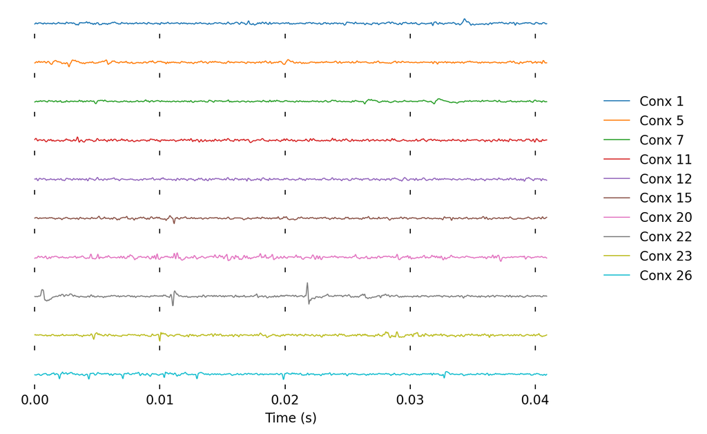

```python
import numpy as np
import pandas as pd
from matplotlib import pyplot as plt

# Prepare data for plotting
data = electrical_series.data[:1000, :10]
timestamps = electrical_series.get_timestamps()[:1000]
df = pd.DataFrame(data)
df["Time (s)"] = timestamps
df.set_index("Time (s)", inplace=True)
df.columns.name = "electrodes"
channel_name_mapper = dict(zip(df.columns, electrical_series.electrodes["channel_name"][:]))
df.rename(channel_name_mapper, axis=1, inplace=True)

fig, axes = plt.subplots(nrows=len(df.columns), sharex=True, sharey=True, dpi=200)
lines = df.plot(subplots=True, ax=axes, legend=False, linewidth=0.8)

# Hide y-axis labels
for ax in axes:
    ax.yaxis.set_visible(False)

# Remove box around the plots
for ax in axes:
    ax.set_frame_on(False)

# Get handles and labels for all lines
handles, labels = [], []
for line in lines:
    h, l = line.get_legend_handles_labels()
    handles.extend(h)
    labels.extend(l)

# Create a single legend box
fig.legend(handles, labels, loc='upper right', bbox_to_anchor=(1.2, 0.8), frameon=False)
plt.xlabel('Time (s)')
plt.tight_layout()
plt.show()
```

The electrodes table describe the electrodes that generated this data. Extracellular electrodes are stored in an "electrodes" table, which is a DynamicTable and can be can be converted to a pandas DataFrame for convenient analysis using `nwbfile.electrodes.to_dataframe()`.

```python
nwbfile.electrodes.to_dataframe().head()
```

| id | location | group | group_name | channel_name | gain_to_uV | offset_to_uV | channel_ids | electrode_type | chamber_type | chamber_x | chamber_y | chamber_z | acx_x | acx_y | acx_z |
| --- | --- | --- | --- | --- | --- | --- | --- | --- | --- | --- | --- | --- | --- | --- | --- |
| 0 | VLa | Group VLa pynwb.ecephys.ElectrodeGroup at 0x14... | Group VLa | Conx 1 | 1.0 | 0.0 | 1 | vp16 | Sagittal | 4.0 | 2.0 | 42.50 | -3.920903 | -5.335591 | 4.325490 |
| 1 | VLa | Group VLa pynwb.ecephys.ElectrodeGroup at 0x14... | Group VLa | Conx 5 | 1.0 | 0.0 | 5 | vp16 | Sagittal | 4.0 | 2.0 | 43.10 | -3.887668 | -5.651801 | 3.816661 |
| 2 | VLa | Group VLa pynwb.ecephys.ElectrodeGroup at 0x14... | Group VLa | Conx 7 | 1.0 | 0.0 | 7 | vp16 | Sagittal | 4.0 | 2.0 | 43.40 | -3.871051 | -5.809906 | 3.562247 |
| 3 | VLa | Group VLa pynwb.ecephys.ElectrodeGroup at 0x14... | Group VLa | Conx 11 | 1.0 | 0.0 | 11 | vp16 | Sagittal | 4.0 | 2.0 | 42.05 | -3.945830 | -5.098434 | 4.707112 |
| 4 | VLa | Group VLa pynwb.ecephys.ElectrodeGroup at 0x14... | Group VLa | Conx 12 | 1.0 | 0.0 | 12 | vp16 | Sagittal | 4.0 | 2.0 | 41.90 | -3.954138 | -5.019382 | 4.834319 |

## Filtered ElectricalSeries

The processed ecephys data is stored in "processing/ecephys" which can be accessed as `nwbfile.processing["ecephys"]`. Within this processing module we can access the container of filtered traces as `nwbfile.processing["ecephys"]["Processed"]` which can hold multiple processed `ElectricalSeries` objects.

```python
nwbfile.processing["ecephys"]
```

ecephys (ProcessingModule)

description: Intermediate data from extracellular electrophysiology recordings, e.g., LFP.

**Processed (FilteredEphys)**

**ElectricalSeriesProcessedGPe (ElectricalSeries)**

starting_time: 9.5367431640625e-07

rate: 24414.0625

resolution: -1.0

comments: no comments

description: High-pass filtered traces (200 Hz) from GPe region.

conversion: 1e-06

offset: 0.0

unit: volts

**data**

HDF5 dataset

| Data type | float32 |
| --- | --- |
| Shape | (33588268, 2) |
| Array size | 256.26 MiB |
| Chunk shape | (1250000, 2) |
| Compression | gzip |
| Compression opts | 4 |
| Uncompressed size (bytes) | 268706144 |
| Compressed size (bytes) | 249582258 |
| Compression ratio | 1.0766235795494725 |

starting_time_unit: seconds

**electrodes (DynamicTableRegion)**

description: electrode_table_region

**table (ElectrodesTable)**

description: metadata about extracellular electrodes

**columns**

**location**

the location of channel within the subject e.g. brain region

**group**

a reference to the ElectrodeGroup this electrode is a part of

**group_name**

the name of the ElectrodeGroup this electrode is a part of

**channel_name**

The channel names from TDT.

**gain_to_uV**

The gain to apply to the traces to convert to microvolts.

**offset_to_uV**

The offset to apply to the traces to convert to microvolts.

**channel_ids**

The identifier of the channels.

**electrode_type**

The type of electrode.

**chamber_type**

The type of the chamber (either Sagittal or Coronal).

**chamber_x**

The medio-lateral coordinate relative to the chamber center, lateral positive, in millimeters.

**chamber_y**

The antero-posterior coordinate relative to the chamber center, posterior negative, in millimeters.

**chamber_z**

The dorso-ventral coordinate relative to the chamber center, ventral positive, in millimeters.

**acx_x**

Medio-lateral coordinate relative to the anterior commissure crossing, lateral positive, in millimeters.

**acx_y**

Antero-posterior coordinate relative to the anterior commissure crossing, posterior negative, in millimeters.

**acx_z**

Dorso-ventral coordinate relative to the anterior commissure crossing, ventral positive, in millimeters.

**table**

| id | location | group | group_name | channel_name | gain_to_uV | offset_to_uV | channel_ids | electrode_type | chamber_type | chamber_x | chamber_y | chamber_z | acx_x | acx_y | acx_z |
| --- | --- | --- | --- | --- | --- | --- | --- | --- | --- | --- | --- | --- | --- | --- | --- |
| 0 | VLa | Group VLa pynwb.ecephys.ElectrodeGroup at 0x140180752687952\nFields:\n description: Group vp16 electrodes.\n device: DeviceEcephys pynwb.device.Device at 0x140180750859104\nFields:\n description: TDT … | Group VLa | Conx 1 | 1.0 | 0.0 | 1 | vp16 | Sagittal | 4.0 | 2.0 | 42.50 | -3.920903 | -5.335591 | 4.325490 |
| 1 | VLa | Group VLa pynwb.ecephys.ElectrodeGroup at 0x140180752687952\nFields:\n description: Group vp16 electrodes.\n device: DeviceEcephys pynwb.device.Device at 0x140180750859104\nFields:\n description: TDT … | Group VLa | Conx 5 | 1.0 | 0.0 | 5 | vp16 | Sagittal | 4.0 | 2.0 | 43.10 | -3.887668 | -5.651801 | 3.816661 |
| 2 | VLa | Group VLa pynwb.ecephys.ElectrodeGroup at 0x140180752687952\nFields:\n description: Group vp16 electrodes.\n device: DeviceEcephys pynwb.device.Device at 0x140180750859104\nFields:\n description: TDT … | Group VLa | Conx 7 | 1.0 | 0.0 | 7 | vp16 | Sagittal | 4.0 | 2.0 | 43.40 | -3.871051 | -5.809906 | 3.562247 |
| 3 | VLa | Group VLa pynwb.ecephys.ElectrodeGroup at 0x140180752687952\nFields:\n description: Group vp16 electrodes.\n device: DeviceEcephys pynwb.device.Device at 0x140180750859104\nFields:\n description: TDT … | Group VLa | Conx 11 | 1.0 | 0.0 | 11 | vp16 | Sagittal | 4.0 | 2.0 | 42.05 | -3.945830 | -5.098434 | 4.707112 |

... and 8 more row(s).

filtering: Equiripple High-pass filter designed using the FIRPM function in MATLAB with a stop-band frequency of 200 Hz, a pass-band frequency of 300 Hz, a stop-band attenuation of 0.0001 dB, a pass-band ripple of 0.057501127785 dB, and a density factor of 20.

**ElectricalSeriesProcessedGPi (ElectricalSeries)**

starting_time: 9.5367431640625e-07

rate: 24414.0625

resolution: -1.0

comments: no comments

description: High-pass filtered traces (200 Hz) from GPi region.

conversion: 1e-06

offset: 0.0

unit: volts

**data**

HDF5 dataset

| Data type | float32 |
| --- | --- |
| Shape | (33588268, 4) |
| Array size | 512.52 MiB |
| Chunk shape | (625000, 4) |
| Compression | gzip |
| Compression opts | 4 |
| Uncompressed size (bytes) | 537412288 |
| Compressed size (bytes) | 500098920 |
| Compression ratio | 1.074611974766912 |

starting_time_unit: seconds

**electrodes (DynamicTableRegion)**

description: electrode_table_region

**table (ElectrodesTable)**

description: metadata about extracellular electrodes

**columns**

**location**

the location of channel within the subject e.g. brain region

**group**

a reference to the ElectrodeGroup this electrode is a part of

**group_name**

the name of the ElectrodeGroup this electrode is a part of

**channel_name**

The channel names from TDT.

**gain_to_uV**

The gain to apply to the traces to convert to microvolts.

**offset_to_uV**

The offset to apply to the traces to convert to microvolts.

**channel_ids**

The identifier of the channels.

**electrode_type**

The type of electrode.

**chamber_type**

The type of the chamber (either Sagittal or Coronal).

**chamber_x**

The medio-lateral coordinate relative to the chamber center, lateral positive, in millimeters.

**chamber_y**

The antero-posterior coordinate relative to the chamber center, posterior negative, in millimeters.

**chamber_z**

The dorso-ventral coordinate relative to the chamber center, ventral positive, in millimeters.

**acx_x**

Medio-lateral coordinate relative to the anterior commissure crossing, lateral positive, in millimeters.

**acx_y**

Antero-posterior coordinate relative to the anterior commissure crossing, posterior negative, in millimeters.

**acx_z**

Dorso-ventral coordinate relative to the anterior commissure crossing, ventral positive, in millimeters.

**table**

| id | location | group | group_name | channel_name | gain_to_uV | offset_to_uV | channel_ids | electrode_type | chamber_type | chamber_x | chamber_y | chamber_z | acx_x | acx_y | acx_z |
| --- | --- | --- | --- | --- | --- | --- | --- | --- | --- | --- | --- | --- | --- | --- | --- |
| 0 | VLa | Group VLa pynwb.ecephys.ElectrodeGroup at 0x140180752687952\nFields:\n description: Group vp16 electrodes.\n device: DeviceEcephys pynwb.device.Device at 0x140180750859104\nFields:\n description: TDT … | Group VLa | Conx 1 | 1.0 | 0.0 | 1 | vp16 | Sagittal | 4.0 | 2.0 | 42.50 | -3.920903 | -5.335591 | 4.325490 |
| 1 | VLa | Group VLa pynwb.ecephys.ElectrodeGroup at 0x140180752687952\nFields:\n description: Group vp16 electrodes.\n device: DeviceEcephys pynwb.device.Device at 0x140180750859104\nFields:\n description: TDT … | Group VLa | Conx 5 | 1.0 | 0.0 | 5 | vp16 | Sagittal | 4.0 | 2.0 | 43.10 | -3.887668 | -5.651801 | 3.816661 |
| 2 | VLa | Group VLa pynwb.ecephys.ElectrodeGroup at 0x140180752687952\nFields:\n description: Group vp16 electrodes.\n device: DeviceEcephys pynwb.device.Device at 0x140180750859104\nFields:\n description: TDT … | Group VLa | Conx 7 | 1.0 | 0.0 | 7 | vp16 | Sagittal | 4.0 | 2.0 | 43.40 | -3.871051 | -5.809906 | 3.562247 |
| 3 | VLa | Group VLa pynwb.ecephys.ElectrodeGroup at 0x140180752687952\nFields:\n description: Group vp16 electrodes.\n device: DeviceEcephys pynwb.device.Device at 0x140180750859104\nFields:\n description: TDT … | Group VLa | Conx 11 | 1.0 | 0.0 | 11 | vp16 | Sagittal | 4.0 | 2.0 | 42.05 | -3.945830 | -5.098434 | 4.707112 |

... and 8 more row(s).

filtering: Equiripple High-pass filter designed using the FIRPM function in MATLAB with a stop-band frequency of 200 Hz, a pass-band frequency of 300 Hz, a stop-band attenuation of 0.0001 dB, a pass-band ripple of 0.057501127785 dB, and a density factor of 20.

**ElectricalSeriesProcessedVLa (ElectricalSeries)**

starting_time: 9.5367431640625e-07

rate: 24414.0625

resolution: -1.0

comments: no comments

description: High-pass filtered traces (200 Hz) from VLa region.

conversion: 1e-06

offset: 0.0

unit: volts

**data**

HDF5 dataset

| Data type | float32 |
| --- | --- |
| Shape | (33588268, 6) |
| Array size | 768.77 MiB |
| Chunk shape | (416666, 6) |
| Compression | gzip |
| Compression opts | 4 |
| Uncompressed size (bytes) | 806118432 |
| Compressed size (bytes) | 748594139 |
| Compression ratio | 1.0768430982866672 |

starting_time_unit: seconds

**electrodes (DynamicTableRegion)**

description: electrode_table_region

**table (ElectrodesTable)**

description: metadata about extracellular electrodes

**columns**

**location**

the location of channel within the subject e.g. brain region

**group**

a reference to the ElectrodeGroup this electrode is a part of

**group_name**

the name of the ElectrodeGroup this electrode is a part of

**channel_name**

The channel names from TDT.

**gain_to_uV**

The gain to apply to the traces to convert to microvolts.

**offset_to_uV**

The offset to apply to the traces to convert to microvolts.

**channel_ids**

The identifier of the channels.

**electrode_type**

The type of electrode.

**chamber_type**

The type of the chamber (either Sagittal or Coronal).

**chamber_x**

The medio-lateral coordinate relative to the chamber center, lateral positive, in millimeters.

**chamber_y**

The antero-posterior coordinate relative to the chamber center, posterior negative, in millimeters.

**chamber_z**

The dorso-ventral coordinate relative to the chamber center, ventral positive, in millimeters.

**acx_x**

Medio-lateral coordinate relative to the anterior commissure crossing, lateral positive, in millimeters.

**acx_y**

Antero-posterior coordinate relative to the anterior commissure crossing, posterior negative, in millimeters.

**acx_z**

Dorso-ventral coordinate relative to the anterior commissure crossing, ventral positive, in millimeters.

**table**

| id | location | group | group_name | channel_name | gain_to_uV | offset_to_uV | channel_ids | electrode_type | chamber_type | chamber_x | chamber_y | chamber_z | acx_x | acx_y | acx_z |
| --- | --- | --- | --- | --- | --- | --- | --- | --- | --- | --- | --- | --- | --- | --- | --- |
| 0 | VLa | Group VLa pynwb.ecephys.ElectrodeGroup at 0x140180752687952\nFields:\n description: Group vp16 electrodes.\n device: DeviceEcephys pynwb.device.Device at 0x140180750859104\nFields:\n description: TDT … | Group VLa | Conx 1 | 1.0 | 0.0 | 1 | vp16 | Sagittal | 4.0 | 2.0 | 42.50 | -3.920903 | -5.335591 | 4.325490 |
| 1 | VLa | Group VLa pynwb.ecephys.ElectrodeGroup at 0x140180752687952\nFields:\n description: Group vp16 electrodes.\n device: DeviceEcephys pynwb.device.Device at 0x140180750859104\nFields:\n description: TDT … | Group VLa | Conx 5 | 1.0 | 0.0 | 5 | vp16 | Sagittal | 4.0 | 2.0 | 43.10 | -3.887668 | -5.651801 | 3.816661 |
| 2 | VLa | Group VLa pynwb.ecephys.ElectrodeGroup at 0x140180752687952\nFields:\n description: Group vp16 electrodes.\n device: DeviceEcephys pynwb.device.Device at 0x140180750859104\nFields:\n description: TDT … | Group VLa | Conx 7 | 1.0 | 0.0 | 7 | vp16 | Sagittal | 4.0 | 2.0 | 43.40 | -3.871051 | -5.809906 | 3.562247 |
| 3 | VLa | Group VLa pynwb.ecephys.ElectrodeGroup at 0x140180752687952\nFields:\n description: Group vp16 electrodes.\n device: DeviceEcephys pynwb.device.Device at 0x140180750859104\nFields:\n description: TDT … | Group VLa | Conx 11 | 1.0 | 0.0 | 11 | vp16 | Sagittal | 4.0 | 2.0 | 42.05 | -3.945830 | -5.098434 | 4.707112 |

... and 8 more row(s).

filtering: Equiripple High-pass filter designed using the FIRPM function in MATLAB with a stop-band frequency of 200 Hz, a pass-band frequency of 300 Hz, a stop-band attenuation of 0.0001 dB, a pass-band ripple of 0.057501127785 dB, and a density factor of 20.

```python
processed_ecephys = nwbfile.processing["ecephys"]["Processed"]

filtered_electrical_series = processed_ecephys["ElectricalSeriesProcessedGPi"]
filtered_electrical_series
```

ElectricalSeriesProcessedGPi (ElectricalSeries)

starting_time: 9.5367431640625e-07

rate: 24414.0625

resolution: -1.0

comments: no comments

description: High-pass filtered traces (200 Hz) from GPi region.

conversion: 1e-06

offset: 0.0

unit: volts

**data**

HDF5 dataset

| Data type | float32 |
| --- | --- |
| Shape | (33588268, 4) |
| Array size | 512.52 MiB |
| Chunk shape | (625000, 4) |
| Compression | gzip |
| Compression opts | 4 |
| Uncompressed size (bytes) | 537412288 |
| Compressed size (bytes) | 500098920 |
| Compression ratio | 1.074611974766912 |

starting_time_unit: seconds

**electrodes (DynamicTableRegion)**

description: electrode_table_region

**table (ElectrodesTable)**

description: metadata about extracellular electrodes

**columns**

**location**

the location of channel within the subject e.g. brain region

**group**

a reference to the ElectrodeGroup this electrode is a part of

**group_name**

the name of the ElectrodeGroup this electrode is a part of

**channel_name**

The channel names from TDT.

**gain_to_uV**

The gain to apply to the traces to convert to microvolts.

**offset_to_uV**

The offset to apply to the traces to convert to microvolts.

**channel_ids**

The identifier of the channels.

**electrode_type**

The type of electrode.

**chamber_type**

The type of the chamber (either Sagittal or Coronal).

**chamber_x**

The medio-lateral coordinate relative to the chamber center, lateral positive, in millimeters.

**chamber_y**

The antero-posterior coordinate relative to the chamber center, posterior negative, in millimeters.

**chamber_z**

The dorso-ventral coordinate relative to the chamber center, ventral positive, in millimeters.

**acx_x**

Medio-lateral coordinate relative to the anterior commissure crossing, lateral positive, in millimeters.

**acx_y**

Antero-posterior coordinate relative to the anterior commissure crossing, posterior negative, in millimeters.

**acx_z**

Dorso-ventral coordinate relative to the anterior commissure crossing, ventral positive, in millimeters.

**table**

| id | location | group | group_name | channel_name | gain_to_uV | offset_to_uV | channel_ids | electrode_type | chamber_type | chamber_x | chamber_y | chamber_z | acx_x | acx_y | acx_z |
| --- | --- | --- | --- | --- | --- | --- | --- | --- | --- | --- | --- | --- | --- | --- | --- |
| 0 | VLa | Group VLa pynwb.ecephys.ElectrodeGroup at 0x140180752687952\nFields:\n description: Group vp16 electrodes.\n device: DeviceEcephys pynwb.device.Device at 0x140180750859104\nFields:\n description: TDT … | Group VLa | Conx 1 | 1.0 | 0.0 | 1 | vp16 | Sagittal | 4.0 | 2.0 | 42.50 | -3.920903 | -5.335591 | 4.325490 |
| 1 | VLa | Group VLa pynwb.ecephys.ElectrodeGroup at 0x140180752687952\nFields:\n description: Group vp16 electrodes.\n device: DeviceEcephys pynwb.device.Device at 0x140180750859104\nFields:\n description: TDT … | Group VLa | Conx 5 | 1.0 | 0.0 | 5 | vp16 | Sagittal | 4.0 | 2.0 | 43.10 | -3.887668 | -5.651801 | 3.816661 |
| 2 | VLa | Group VLa pynwb.ecephys.ElectrodeGroup at 0x140180752687952\nFields:\n description: Group vp16 electrodes.\n device: DeviceEcephys pynwb.device.Device at 0x140180750859104\nFields:\n description: TDT … | Group VLa | Conx 7 | 1.0 | 0.0 | 7 | vp16 | Sagittal | 4.0 | 2.0 | 43.40 | -3.871051 | -5.809906 | 3.562247 |
| 3 | VLa | Group VLa pynwb.ecephys.ElectrodeGroup at 0x140180752687952\nFields:\n description: Group vp16 electrodes.\n device: DeviceEcephys pynwb.device.Device at 0x140180750859104\nFields:\n description: TDT … | Group VLa | Conx 11 | 1.0 | 0.0 | 11 | vp16 | Sagittal | 4.0 | 2.0 | 42.05 | -3.945830 | -5.098434 | 4.707112 |

... and 8 more row(s).

filtering: Equiripple High-pass filter designed using the FIRPM function in MATLAB with a stop-band frequency of 200 Hz, a pass-band frequency of 300 Hz, a stop-band attenuation of 0.0001 dB, a pass-band ripple of 0.057501127785 dB, and a density factor of 20.

# Access Units

Spike times are stored in the `Units` table, which is a DynamicTable and can be can be converted to a pandas DataFrame for convenient analysis using `nwbfile.units.to_dataframe()`.

```python
nwbfile.units[:]
```

| id | spike_times | unit_name | sort_label | location | channel_ids | unit_quality_post_sorting |
| --- | --- | --- | --- | --- | --- | --- |
| 0 | [0.03395584, 0.0520192, 0.12259328, 0.16719872... | 0 | 1.0 | VLa | 1 | excellent |
| 1 | [1.32456448, 5.83467008, 5.99814144, 6.0211609... | 1 | 1.0 | VLa | 5 | excellent |
| 2 | [0.00217088, 0.10825728, 0.1626112, 0.23588864... | 2 | 2.0 | VLa | 5 | excellent |
| 3 | [0.8450048, 1.18214656, 4.81329152, 6.4045056,... | 3 | 1.0 | VLa | 7 | good |
| 4 | [0.09691136, 0.1282048, 0.15757312, 0.25923584... | 4 | 1.0 | VLa | 11 | good |
| 5 | [0.04907008, 0.116736, 0.15835136, 0.18751488,... | 5 | 1.0 | VLa | 12 | excellent |
| 6 | [0.01056768, 0.08716288, 0.09531392, 0.1458585... | 6 | 1.0 | VLa | 15 | excellent |
| 7 | [2.70639104, 9.90437376, 10.7485184, 25.959055... | 7 | 1.0 | GPi | 20 | F |
| 8 | [0.02125824, 0.09744384, 0.17870848, 0.2081587... | 8 | 1.0 | GPi | 22 | excellent |
| 9 | [0.01036288, 0.055296, 0.09613312, 0.1349632, ... | 9 | 2.0 | GPi | 22 | good |
| 10 | [0.10190848, 0.13770752, 0.1859584, 0.26558464... | 10 | 3.0 | GPi | 22 | good |
| 11 | [0.063488, 0.0784384, 0.72880128, 1.0031104, 1... | 11 | 4.0 | GPi | 22 | good |
| 12 | [0.1062912, 0.19480576, 0.33542144, 0.34828288... | 12 | 1.0 | GPi | 23 | excellent |
| 13 | [0.00405504, 0.00933888, 0.0514048, 0.06397952... | 13 | 2.0 | GPi | 23 | good |
| 14 | [0.00131072, 0.00364544, 0.0063488, 0.00970752... | 14 | 1.0 | GPi | 26 | excellent |
| 15 | [0.34803712, 1.18255616, 1.44543744, 1.4502707... | 15 | 1.0 | GPe | 28 | excellent |
| 16 | [0.03166208, 0.05963776, 0.0618496, 0.07155712... | 16 | 1.0 | GPe | 31 | excellent |

### Interactive visualization of spike times

[figure not shown]

Visit Neurosift

### PSTH

In this example we will show the activity of two single units sampled from VLa and GPi region aligned to the time of movement onset.

We will use [Pynapple](https://pynapple-org.github.io/pynapple/) to compute and visualize the PSTH using the `pynapple.compute_perievent()` method.

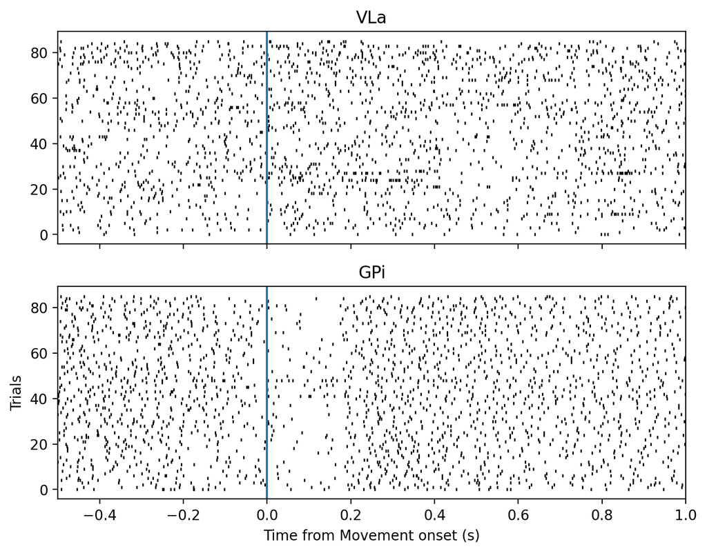

```python
from matplotlib import pyplot as plt
import pynapple as nap

movement_onset_ts = nap.Ts(nwbfile.trials["movement_start_time"][:], time_units="s")
spike_times_group = nap.TsGroup({unit_ind: nap.Ts(spikes) for unit_ind, spikes in enumerate(nwbfile.units["spike_times"])})

perievent_histogram = nap.compute_perievent(
    data=spike_times_group,
    tref=movement_onset_ts,
    minmax=(-0.5, 1),
    time_unit="s",
)



fig, ax = plt.subplots(nrows=2, ncols=1, figsize=(8, 6), dpi=200, sharex=True, sharey=True)
ax[0].plot(
    perievent_histogram[0].to_tsd(),
    "|",
    color="black",
    markersize=2,
)
ax[0].set_title(nwbfile.units[0]["location"].values[0])
ax[0].axvline(0.0)

ax[1].plot(
    perievent_histogram[11].to_tsd(),
    "|",
    color="black",
    markersize=2,
)
ax[1].set_title(nwbfile.units[11]["location"].values[0])
ax[1].axvline(0.0)

plt.xlabel("Time from Movement onset (s)")
plt.ylabel("Trials")
plt.xlim(-0.5, 1)
plt.show()
```

We can also use Neurosift for this visualization:

[figure not shown]